# 102_satwind

## bufr

El viento derivado de satélites se codifica como tipo 240 - 260 dependiendo del instrumento. Sin embargo ni GFS ni el resto de los sistemas operativos usan las observaciones presentes en el prepbufr y en cambio leen el bufr específico **gdas.tHHz.satwnd.tm00.bufr_D**.

En la [Tabla 18](https://www.emc.ncep.noaa.gov/mmb/data_processing/prepbufr.doc/table_18.htm) se detalla el uso de las distintas observaciones según el instrumento.

### Satwnd Header Definitions:

- DATACAT = BUFR Data Category
- SAID = Satellite Identifier
- OCID = Identification of originating/generating center (GCLONG in BUFR)
- CLAS = Satellite Classification (SCLF in BUFR)
- RPID = Report Identifier
- SIDP = Satellite Used in Instrument Processing
- SWCM = Satellite Derived Wind Computation Method
- YEAR = YEAR
- MNTH = MONTH
- DAY = DAY
- HOUR = HOUR
- MIN = MIN
- LAT = Latitude (Deg)
- LON = Longitude (Deg)
- PRSL = Pressure (Pa)
- TMP = Temperature/Dry Bulb Temperature (K)
- WDIR = Wind Direction (Degree True)
- WSPD = Wind Speed (m/s)

Mejor y con más detalle [Tabla b](https://www.nco.ncep.noaa.gov/sib/jeff/bufrtab_tableb.html)

### GSI

**read_obs.f90**

- Reconoce el bufr de este tipo de observaciones si el archivo se llama **satwndbufr** y llama a la rutina **read_satwnd**

**read_satwnd.f90**

For the satellite ID type:

- 240: GOES short wave winds,
- 241: India,
- 242: JMA Visible,
- 243: EUMETSAT visible,
- 244: AVHRR winds
- 245: GOES IR.
- 246: GOES WV cloud top,
- 247: GOES WV deep layer
- 250: JMA WV deep layer.
- 251: GOES visible,
- 252: JMA IR winds
- 253: EUMETSAT IR winds,
- 254: EUMETSAT WV deep layer winds
- 257,258,259: MODIS IR,WV cloud top, WV deep layer winds
- 260: VIIR IR winds

For satellite subtype:

- 50-80 from EUMETSAT geostationary satellites(METEOSAT)
- 100-199 from JMA geostationary satellites(MTSAT)
- 250-299 from NESDIS geostationary satellites(GOES)
- 700-799 from NASA Terra and Aqua satellites
- <10, 200-223 from NOAA-15, 16, 17, 18, polar orbit and EUMESAT MetOp satellites

The quality mark:the values range from 0 to 15.

- 0-7 used: 0 is best, when the value greater than 3, the observation error needed to be enflated.
- 8-15 monitored

Notas:

- Rechaza observaciones por encima de 125mb.
- Rechaza observaciones con quality marker 12 o 14.
- Algunas restricciones extras dependiendo del tipo de observación, por ejemplo:
  - Velocidad mínima de 10m/s para CAWV (type = 247), qm = 15
  - qm=15 !reject data with low QI

#### diagfile

- cdata_all(1,iout)=woe ! wind error
- cdata_all(2,iout)=dlon ! grid relative longitude
- cdata_all(3,iout)=dlat ! grid relative latitude
- cdata_all(4,iout)=dlnpob ! ln(pressure in cb)
- cdata_all(5,iout)=ee ! quality information
- cdata_all(6,iout)=uob ! u obs
- cdata_all(7,iout)=vob ! v obs
- cdata_all(8,iout)=rstation_id ! station id
- cdata_all(9,iout)=t4dv ! time
- cdata_all(10,iout)=nc ! index of type in convinfo file
- cdata_all(11,iout)=qifn +1000.0_r_kind*qify ! quality mark infor
- cdata_all(12,iout)=qm ! quality mark
- cdata_all(13,iout)=obserr ! original obs error
- cdata_all(14,iout)=usage ! usage parameter
- cdata_all(15,iout)=idomsfc ! dominate surface type
- cdata_all(16,iout)=tsavg ! skin temperature
- cdata_all(17,iout)=ff10 ! 10 meter wind factor
- cdata_all(18,iout)=sfcr ! surface roughness
- cdata_all(19,iout)=dlon_earth_deg ! earth relative longitude (degrees)
- cdata_all(20,iout)=dlat_earth_deg ! earth relative latitude (degrees)
- cdata_all(21,iout)=zz ! terrain height at ob location
- cdata_all(22,iout)=r_prvstg(1,1) ! provider name
- cdata_all(23,iout)=r_sprvstg(1,1) ! subprovider name
- cdata_all(25,iout)=var_jb ! non linear qc parameter

### Comparación analisis con y sin satwnd

Prueba de asimilación usando 3DVar para hacer un par de experimentos rápidos.

Fecha: 2018112100

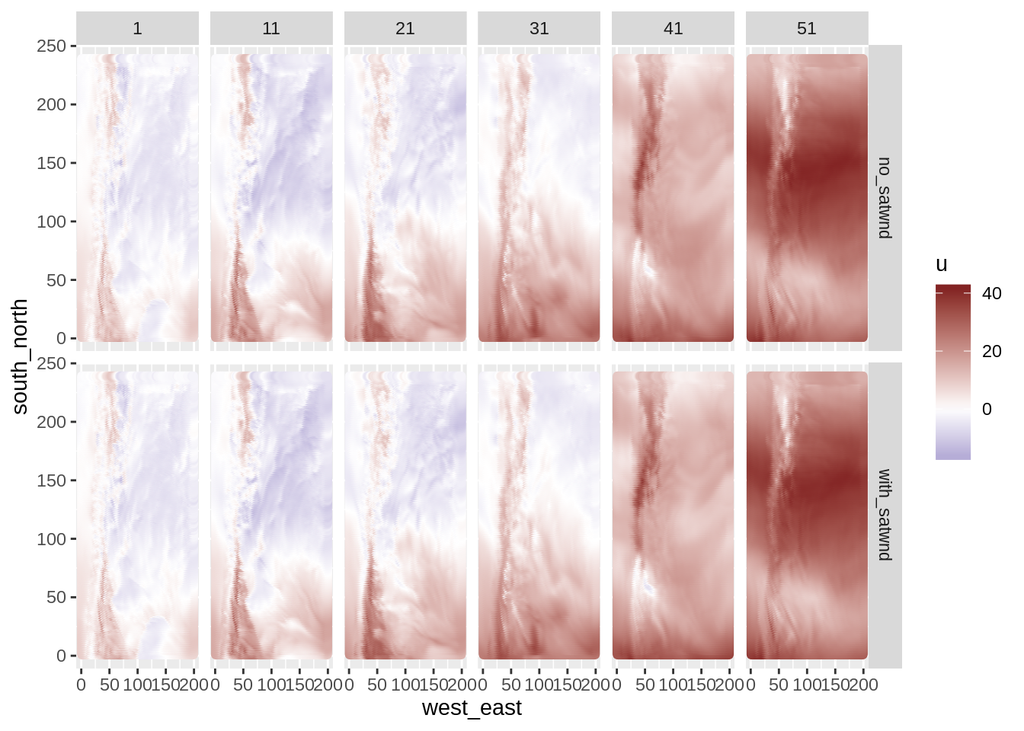

```r
exp[bottom_top %in% seq(1, 60, 10)] %>%
  ggplot(aes(west_east, south_north)) +
  geom_point(aes(color = u)) +
  scale_color_divergent() +
  facet_grid(exp~bottom_top)
```

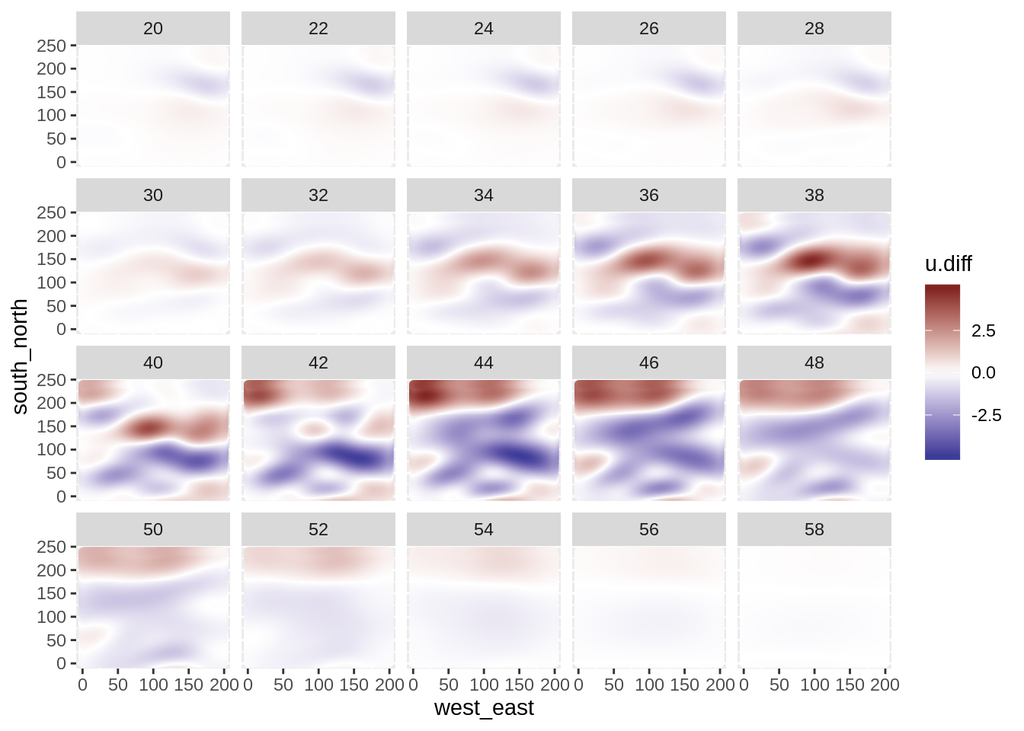

```r
diff[bottom_top %in% seq(20, 58, 2)] %>%
  ggplot(aes(west_east, south_north)) +
  geom_point(aes(color = u.diff)) +
  scale_color_divergent() +
  facet_wrap(~bottom_top)
```

### Diagfiles

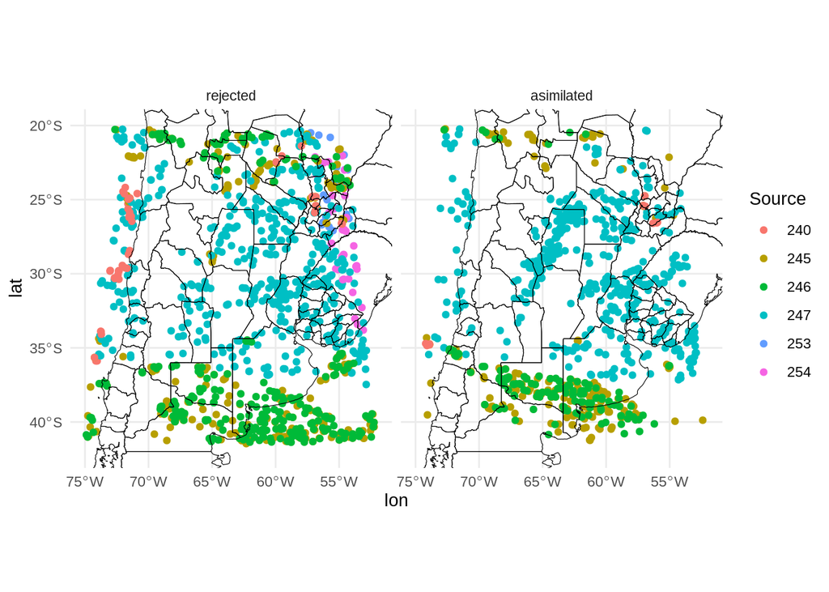

```r
diag <- fread("/home/paola.corrales/comGSIv3.7_EnKFv1.3/examples/test/gsi_satwnd/results_conv_ges.2018112100") %>%
  .[, c("V2", "V4") := NULL]

colnames(diag) <- c("var", "stationID", "type", "dhr", "lat", "lon", "pressure", "usage.flag", "obs", "obs.guess", "obs2", "obs.guess2", "rerr")

diag[type %between% c(240, 260)] %>%
  ggplot(aes(ConvertLongitude(lon), lat)) +
  geom_point(aes(color = factor(type))) +
  geom_mapa() +
  coord_sf(xlim = c(-75, -52), ylim = c(-42,-20)) +
  facet_wrap(~usage.flag, labeller = labeller(usage.flag = c("-1" = "rejected",
                                                             "1" = "asimilated"))) +
  labs(color = "Source",
       x = "lon") +
  theme_minimal()
```

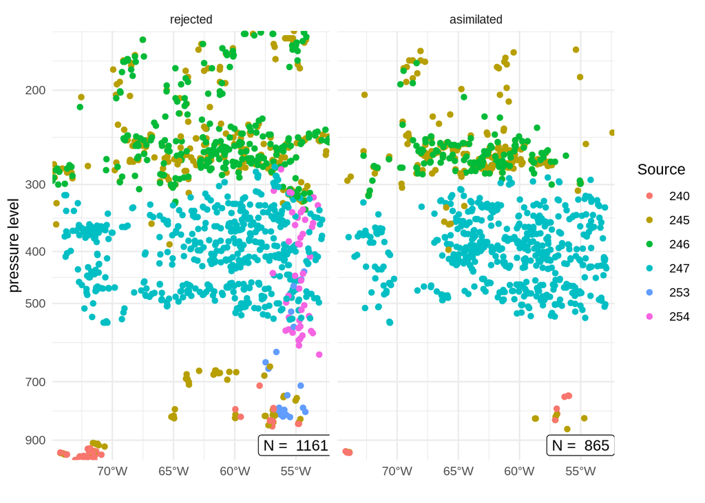

```r
N_obs <- diag[type %between% c(240, 260), .N, by = usage.flag] %>%
  .[, label := paste("N = ", N)] %>%
  .[, ":="(lon = 305.0,
          pressure = 920)]

diag[type %between% c(240, 260)] %>%
  ggplot(aes(ConvertLongitude(lon), pressure)) +
  geom_point(aes(color = factor(type))) +
  scale_y_level(name = "pressure level", breaks = c(1000, 900, 700, 500, 400, 300, 200, 100)) +
  scale_x_longitude(breaks = seq(-75, -55, 5)) +
  geom_label(data = N_obs, aes(x = ConvertLongitude(lon), y = pressure, label = label))  +
  facet_wrap(~usage.flag, labeller = labeller(usage.flag = c("-1" = "rejected",
                                                             "1" = "asimilated"))) +
  labs(color = "Source",
       x = "lon",
       y = "pressure level") +
  theme_minimal()
```